#### **To: Quian and General Mills Management**

#### **From: Andrew Nalundasan and Jordan Gropper**

#### **Date: July 29, 2021**

#### **RE: Findings and actions for advertisement campaign and promotion strategies**

We have completed an analysis on the effectiveness of in-store promotions and advertisement campaigns for General Mills (GM). This memo includes details about our findings and recommendations from our study. The provided dataset had 21,850 observations of weekly sales information for GM and our two closest competitors, Kellogg’s and Post. The dataset was used to better understand the relationship between prices, units sold, brands, flavors, packaging, promotions, and advertisement campaigns. In this study, we identify the top performing stores and determine which brands of cereal are the top sellers, and compare performance between small and medium sized advertisement campaigns. To conclude this memo, we suggest recommendations of actions that GM could take regarding in-store promotion and advertisement strategies to enhance its competition within the cereal market.

It was found that Kellogg’s is the only company from our dataset with a positive sales trend for the year. We first analyzed in-store promotions to identify ways to help boost GM’s annual sales performance.

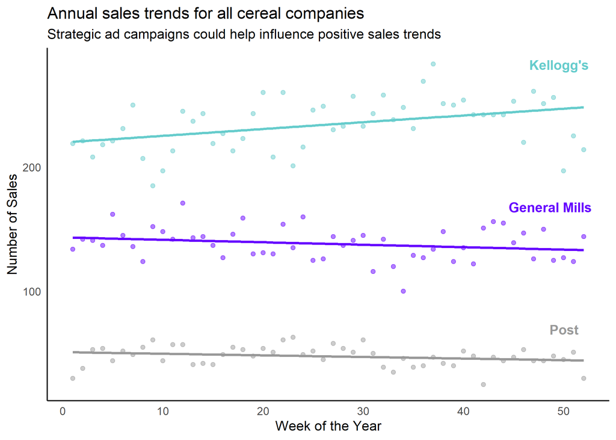

In-store promotions were found to sometimes discount cereal up to 25% of their actual value. In these drastically discounted scenarios, it would be necessary to sell up to four units for GM to break even. To optimize GM’s in-store promotion strategy, we identified the top five performing stores that experienced increased sales during promotions and determined the best selling brands at those stores. As you can see in the table below, the labeled stores outsold the others when it came to selling promoted items.

Top 5 performing stores with top GM branded cereal during in-store promotion

| Store Number | Best Brand | Median Units Sold |
| --- | --- | --- |
| 230514 | Lucky Charms | 28 |
| 233072 | Cinnamon Toast Crunch | 28 |
| 240824 | Lucky Charms | 28 |
| 241553 | Cinnamon Toast Crunch | 28 |
| 243941 | Cocoa Puffs | 28 |

A revamping of in-store promotion strategy would enable GM to compete better in this market. It was found that each store above sold 28 median units of the top brands: Lucky Charms, Cinnamon Toast Crunch, and Cocoa Puffs. We encourage GM to apply similar in-store promotion strategies effective at the stores highlighted above to all stores that sell GM products. To compare GM to the market as a whole, the cereal market experienced much lower sales depending on in-store promotions. When there were no in-store promotions in effect, a median of 6 units were sold while a median of 10 units were sold during promotions. Implementing in-store promotion strategies similar to what the top five stores have in effect would help GM to boost sales.

In addition to promotions, optimizing GM’s advertisement campaigns is very important, as we are in direct competition with Kellogg’s. Maximizing our investments in campaigns that have practical effect on sales will enable us to sell more cereal at a lower advertisement cost, allowing us to grow our annual sales. As the graph above depicts, currently our sales decline over the year, where as Kelloggs’ increases. To further assist in the increase of GM’s sales, our second recommendation was developed by analyzing the performance of GM’s two different advertisement campaigns: small and medium. Going into this analysis, we assume that medium sized campaigns cost more to launch and maintain compared to a small sized campaign.

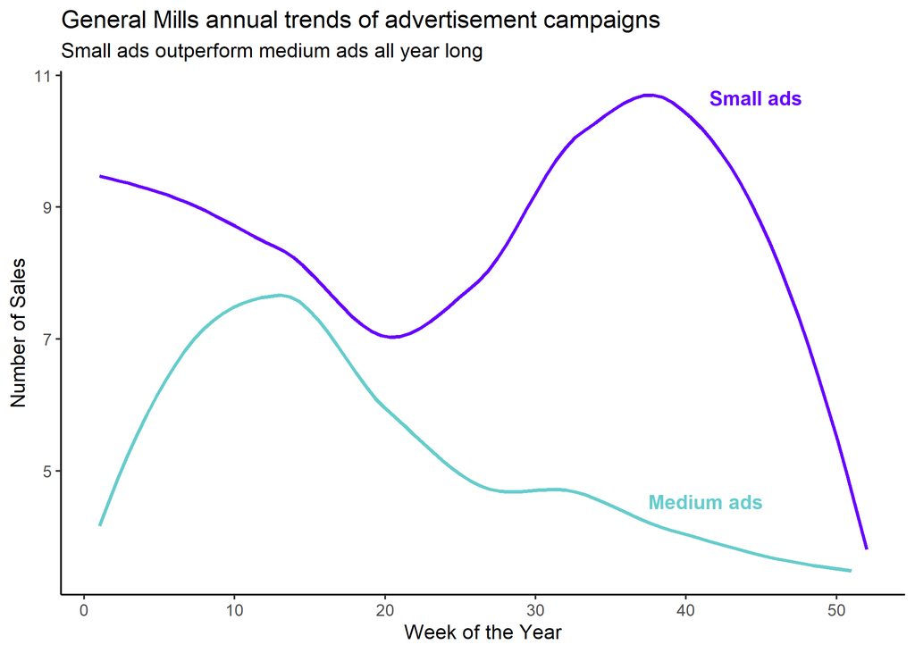

In conclusion, we were able to identify and recommend two distinct ways of guiding GM to decrease advertisement costs and increase our potential to sell more cereal. Focusing on small campaigns and optimizing our in-store promotion strategies by modeling our top five performing stores will help us to compete in this market. The first step is to implement these recommendations to influence sales trends. A future study should be performed to validate these recommendations to ensure that sales begin increasing. When sales begin increasing, additional future studies could be done to optimize profits. If you have any questions about the research done, please feel free to reach out to our team. Our Technical Appendix with our complete analysis has been included with this submission.

Best,

Jordan Gropper and Andrew Nalundasan